# CS 372/472 & LRN_SCI 372/472

Designing and Constructing Models with Multi-Agent Languages

Dr. Connor Bain

connor.bain@northwestern.edu

April 2, 2026

## What is this class?

### And what **isn’t** this class?

This *is* a course about **artificial intelligence** (AI)

- But this is NOT a course about *large language models* (LLMs).

This *is* a course about **agents**

- But this is NOT a course about using LLM-based agents.

This *is* a course about **complex systems** and **emergence**

- What they are
- How they are studied
- What we can learn from them

## About Me - Connor Bain (connor.bain@northwestern.edu)

- Undergrad at the **University of South Carolina** in CS, Math, and Music
- MS/PhD from **Northwestern University** in CS and Learning Sciences
  - I was a PhD student in the Center for Connected Learning and Computer-based Modeling
  - I was the main NetLogo Models Library Editor from 2016 - 2021
- This quarter I’m teaching:
  - `CS 372/472` - Multi-agent based Modeling and Simulation
  - `CS 396/496` - Pedagogical Design in CS (TeachCS)
- My research focuses on all aspects of the idea of computational literacy and on how teachers can harness computational literacy in their own classrooms.
- My office is TCH L374

## Complex Systems

**Definition**

A **complex system** is a system with a large number of interacting parts that evolves over time.

- Decentralized decisions as opposed to centralized control
- Global patterns *emerge* from local interactions and decisions
- Examples are all around us!
  - Ecosystems
  - Economies
  - Immune systems

## Emergent Phenomena

**Definition**

We’ll define an **emergent phenomena** as a macro-level pattern that occurs as the result of micro-level rules and structures.

- In essence, it’s order without design
  - there’s no “leader” or “orchestrator” of the pattern
  - it’s probabilistic and decentralized control
  - or in other words, the interactions of distributed *agents*
- Examples:
  - The structure of a beehive
  - Variations of a population in an ecosystem
  - Pressure of a gas
  - Traffic jams

# Emergence is hard for humans to navigate

## Agents Circling

- Agents start on a circle, facing around it
- At each tick of the clock agents move forward and turn a tiny bit, forming a circle of a given radius

**Question**

If we change the radius of the circle each agent is making, how will the global pattern change?

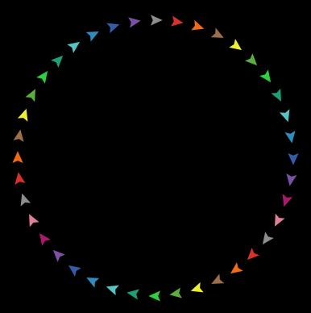

## How can we model such things?

- We could express the agents’ behaviors mathematically. Imagine simplifying their movements to a system of differential equations. (*yuck*)
- Or we could physically simulate agents by building a machine in the real world to follow our rules
- Or we could try to simulate those rules in our heads (turns out…humans are generally really bad at this)
- This class takes the stance that we can use specialized computer-based modeling languages to express agent’s behaviors

**Definition**

A **computational model** is a model that takes certain input values, manipulates those inputs in an algorithmic way, and generates outputs.

## What is an agent?

**Definition**

An **agent** is an autonomous individual element of a computer simulation.

In our course agents will have:

- properties
- states
- behaviors

## So what is agent-based modeling?

**Definition**

An **agent-based model (ABM)** is a form of computational model that enables us to give agents behaviors. The methodology of ABM encodes the behavior of individual agents in *simple rules* and then observes and analyzes the results of these agents’ interactions.

ABMs can be used to model and describe a wide variety of processes, phenomena, and situations:

- Molecules in a chemical reaction
- Buyers/sellers in an economy
- Organisms in an ecosystem

## How will we build ABMs?

In this course we’ll be using a [ABM language and environment called NetLogo](https://www.netlogo.org/downloads/)

- This is a free and open source ABM environment built right here at Norhtwestern with NSF Support
- It has hundreds of thousands of users across basically every domain
- It is specifically designed to be high-ceiling and low-floor
- It was created for modeling complex systems: emergent phenomena, evolutionary systems, & dynamic networks
- It has three core types of agents: turtles, patches, and links
  - Supports 1000s of simultaneous agents of all types – all in parallel

# NetLogo Intro and Demos

## Fire Simple ABM - Rules

### SETUP

- Each `patch`:
  - Am I on the left edge? If so, I turn red.
  - Otherwise, I spin a dial (from `0 -100`). If the value is less than the `DENSITY` slider, I turn green.

### GO (at each clock tick)

- Each `red patch`:
  - I “talk to” my 4 cardinal neighbors and “ask”: if any of you are green, turn red.

## Sheep Simple ABM - Rules

### GO (at each clock tick)

- Each `sheep`:
  - I move randomly and lose a little energy
  - If grass on my patch, turn patch brown, increase my energy
  - If `energy < 0` then `die`
- Each `patch`
  - If my `pcolor` is brown, I turn green with probability `GRASS-GROWTH-RATE`.

## Ants Simple ABM - Rules

- Create an ant nest in the middle of the world & create three food piles.
- Create `POPULATION` ants all located in the nest.

### GO (at each clock tick)

- Each `ant`:
  - I will turn randomly a small amount and move forward.
  - If I am not carrying food, I’ll sense for a pheromone trail nearby and if I find one then I will turn toward its strongest source. Otherwise, I’ll turn toward the nest and drop some pheremone.
- Each `patch`:
  - Evaporate a percentage, set by `EVAPORATION-RATE`, of my pheromone.
  - Diffuse a percentage, set by `DIFFUSION-RATE`, of my pheromone to my eight neighboring patches.

# Course Specifics + Syllabus

## Understanding Complexity

The secret to understanding much of the world’s complexity is to model that complexity as the result of many distributed individuals (agents) following a few simple rules.

**Lots of science!**

Model implementation and study is used a legitimate form of scientific inquiry and discovery. [Here are lots of examples](https://www.netlogo.org/references/)!